# december_project

lnguen_1

24/12/2019

```
## [1] "churn"   "country"
```

##1. исследуйте разные подгруппы клиентов/сотрудников. Выделите подгруппу, которая представляет наибольший интерес, обоснуйте свой выбор

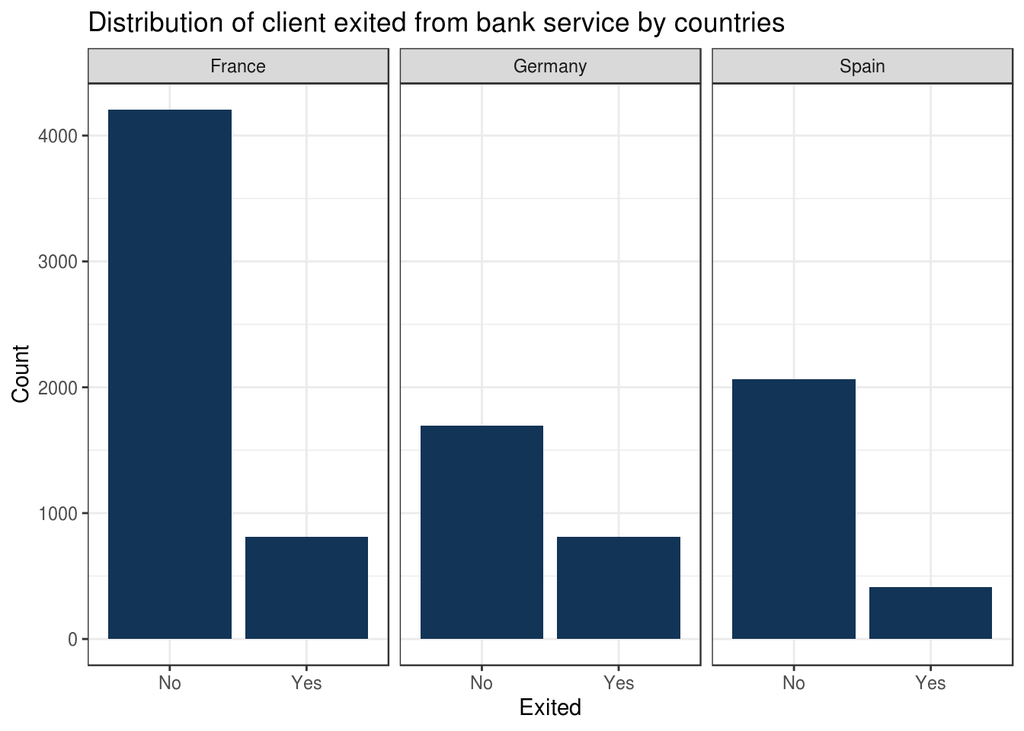

##2. постройте модель для предсказания оттока (любым методом на ваш выбор)

### Model 1: ctree

### Model 2: Logit

### Model 3: Linear

### Model 4: randomForest

### Model 5: Gradient boosting

```
## [1] "Accuracy of tree model is: 0.857428714357179"
```

```
## [1] "Accuracy of logit model is: 0.848424212106053"
```

```
## [1] "Best split at 1.34784911585909"
```

```
## [1] "Accuracy of linear model is: 0.84592296148074"
```

```
## [1] "Accuracy of random-forest model is: 0.862931465732866"
```

```
## [1] "Accuracy of boosting model is: 0.867433716858429"
```

##3. * выявите основные факторы, которые значимы для предсказания оттока согласно этой модели

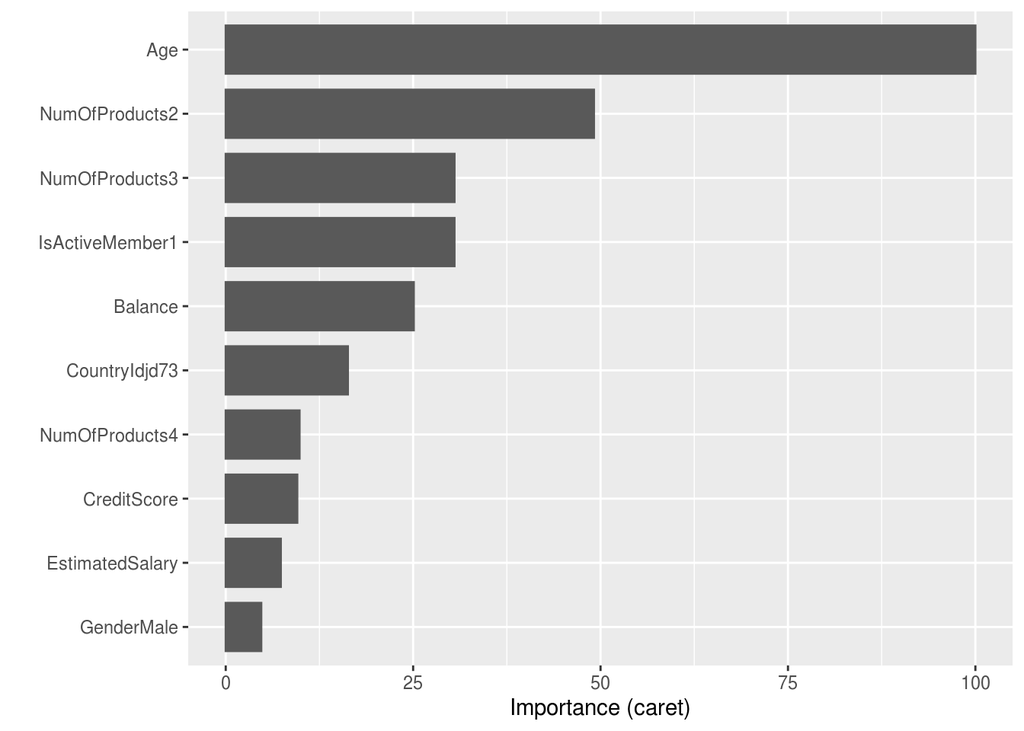

##4. предложите, какие действия могла бы предпринять компания, чтобы предотвратить/уменьшить отток. Обоснуйте свои предложения

Приведенная выше диаграмма отражает, что Age, NumberOfProduct, IsActivaMember являются наиболее важными переменными, влияющими на результаты прогнозирования Exited / NoExited. Поэтому у меня было несколько предложений для банка: 1. Предложение соответствующих пакетов услуг для стимулирования клиентов использовать многие продукты и услуги клиентов. 2. Ориентируйтесь на клиентов моложе 44 лет 3. Сосредоточьтесь на клиентах-женщинах, потому что они чаще отказываются от банковских услуг, чем мужчины.

####Пример объяснения с данными, на которых была построена модель:

[interactive chart not shown]

##5. протестируйте с помощью предсказаний эффект от ваших предложений